# Risk Factor Analysis

## Outcome Variable

**Outcome Variable:** haz

## Predictor Variables

**Intervention Variable:** feducyrs

**Adjustment Set:**

- arm
- W_mage
- meducyrs
- hhwealth_quart
- W_mhtcm
- W_mwtkg
- W_mbmi
- W_gagebrth
- W_birthwt
- W_birthlen
- single
- impsan
- delta_W_mage
- delta_meducyrs
- delta_hhwealth_quart
- delta_W_mhtcm
- delta_W_mwtkg
- delta_W_mbmi
- delta_W_gagebrth
- delta_W_birthwt
- delta_W_birthlen
- delta_single
- delta_impsan

## Stratifying Variables

The analysis was stratified on these variable(s):

- agecat
- studyid
- country

## Data Summary

| agecat | studyid | country | feducyrs | n_cell | n | outcome_variable |
| --- | --- | --- | --- | --- | --- | --- |
| Birth | COHORTS | GUATEMALA | High | 155 | 804 | haz |
| Birth | COHORTS | GUATEMALA | Low | 355 | 804 | haz |
| Birth | COHORTS | GUATEMALA | Medium | 294 | 804 | haz |
| Birth | COHORTS | INDIA | High | 527 | 1354 | haz |
| Birth | COHORTS | INDIA | Low | 439 | 1354 | haz |
| Birth | COHORTS | INDIA | Medium | 388 | 1354 | haz |
| Birth | COHORTS | PHILIPPINES | High | 1027 | 2873 | haz |
| Birth | COHORTS | PHILIPPINES | Low | 827 | 2873 | haz |
| Birth | COHORTS | PHILIPPINES | Medium | 1019 | 2873 | haz |
| Birth | GMS-Nepal | NEPAL | High | 172 | 694 | haz |
| Birth | GMS-Nepal | NEPAL | Low | 296 | 694 | haz |
| Birth | GMS-Nepal | NEPAL | Medium | 226 | 694 | haz |
| Birth | JiVitA-3 | BANGLADESH | High | 4726 | 21624 | haz |
| Birth | JiVitA-3 | BANGLADESH | Low | 9468 | 21624 | haz |
| Birth | JiVitA-3 | BANGLADESH | Medium | 7430 | 21624 | haz |
| Birth | JiVitA-4 | BANGLADESH | High | 582 | 2740 | haz |
| Birth | JiVitA-4 | BANGLADESH | Low | 1102 | 2740 | haz |
| Birth | JiVitA-4 | BANGLADESH | Medium | 1056 | 2740 | haz |
| Birth | MAL-ED | BANGLADESH | High | 47 | 129 | haz |
| Birth | MAL-ED | BANGLADESH | Low | 36 | 129 | haz |
| Birth | MAL-ED | BANGLADESH | Medium | 46 | 129 | haz |
| Birth | MAL-ED | INDIA | High | 7 | 24 | haz |
| Birth | MAL-ED | INDIA | Low | 14 | 24 | haz |
| Birth | MAL-ED | INDIA | Medium | 3 | 24 | haz |
| Birth | MAL-ED | NEPAL | High | 3 | 10 | haz |
| Birth | MAL-ED | NEPAL | Low | 4 | 10 | haz |
| Birth | MAL-ED | NEPAL | Medium | 3 | 10 | haz |
| Birth | MAL-ED | PERU | High | 86 | 194 | haz |
| Birth | MAL-ED | PERU | Low | 58 | 194 | haz |
| Birth | MAL-ED | PERU | Medium | 50 | 194 | haz |

[output cut: 135 more lines]

The following strata were considered:

- agecat: 24 months, studyid: COHORTS, country: GUATEMALA
- agecat: 24 months, studyid: COHORTS, country: INDIA
- agecat: 24 months, studyid: COHORTS, country: PHILIPPINES
- agecat: 24 months, studyid: GMS-Nepal, country: NEPAL
- agecat: 24 months, studyid: JiVitA-3, country: BANGLADESH
- agecat: 24 months, studyid: JiVitA-4, country: BANGLADESH
- agecat: 24 months, studyid: LCNI-5, country: MALAWI
- agecat: 24 months, studyid: MAL-ED, country: BANGLADESH
- agecat: 24 months, studyid: MAL-ED, country: INDIA
- agecat: 24 months, studyid: MAL-ED, country: NEPAL
- agecat: 24 months, studyid: MAL-ED, country: PERU
- agecat: 24 months, studyid: MAL-ED, country: SOUTH AFRICA
- agecat: 24 months, studyid: MAL-ED, country: TANZANIA, UNITED REPUBLIC OF
- agecat: 24 months, studyid: NIH-Crypto, country: BANGLADESH
- agecat: 24 months, studyid: PROBIT, country: BELARUS
- agecat: 24 months, studyid: PROVIDE, country: BANGLADESH
- agecat: 24 months, studyid: TanzaniaChild2, country: TANZANIA, UNITED REPUBLIC OF
- agecat: 24 months, studyid: ZVITAMBO, country: ZIMBABWE
- agecat: 6 months, studyid: COHORTS, country: GUATEMALA
- agecat: 6 months, studyid: COHORTS, country: INDIA
- agecat: 6 months, studyid: COHORTS, country: PHILIPPINES
- agecat: 6 months, studyid: GMS-Nepal, country: NEPAL
- agecat: 6 months, studyid: JiVitA-3, country: BANGLADESH
- agecat: 6 months, studyid: JiVitA-4, country: BANGLADESH
- agecat: 6 months, studyid: LCNI-5, country: MALAWI
- agecat: 6 months, studyid: MAL-ED, country: BANGLADESH
- agecat: 6 months, studyid: MAL-ED, country: INDIA
- agecat: 6 months, studyid: MAL-ED, country: NEPAL
- agecat: 6 months, studyid: MAL-ED, country: PERU
- agecat: 6 months, studyid: MAL-ED, country: SOUTH AFRICA
- agecat: 6 months, studyid: MAL-ED, country: TANZANIA, UNITED REPUBLIC OF
- agecat: 6 months, studyid: NIH-Crypto, country: BANGLADESH
- agecat: 6 months, studyid: PROBIT, country: BELARUS
- agecat: 6 months, studyid: PROVIDE, country: BANGLADESH
- agecat: 6 months, studyid: SAS-CompFeed, country: INDIA
- agecat: 6 months, studyid: SAS-FoodSuppl, country: INDIA
- agecat: 6 months, studyid: TanzaniaChild2, country: TANZANIA, UNITED REPUBLIC OF
- agecat: 6 months, studyid: ZVITAMBO, country: ZIMBABWE
- agecat: Birth, studyid: COHORTS, country: GUATEMALA
- agecat: Birth, studyid: COHORTS, country: INDIA
- agecat: Birth, studyid: COHORTS, country: PHILIPPINES
- agecat: Birth, studyid: GMS-Nepal, country: NEPAL
- agecat: Birth, studyid: JiVitA-3, country: BANGLADESH
- agecat: Birth, studyid: JiVitA-4, country: BANGLADESH
- agecat: Birth, studyid: MAL-ED, country: BANGLADESH
- agecat: Birth, studyid: MAL-ED, country: INDIA
- agecat: Birth, studyid: MAL-ED, country: NEPAL
- agecat: Birth, studyid: MAL-ED, country: PERU
- agecat: Birth, studyid: MAL-ED, country: SOUTH AFRICA
- agecat: Birth, studyid: MAL-ED, country: TANZANIA, UNITED REPUBLIC OF
- agecat: Birth, studyid: NIH-Crypto, country: BANGLADESH
- agecat: Birth, studyid: PROBIT, country: BELARUS
- agecat: Birth, studyid: PROVIDE, country: BANGLADESH
- agecat: Birth, studyid: SAS-CompFeed, country: INDIA
- agecat: Birth, studyid: ZVITAMBO, country: ZIMBABWE

### Dropped Strata

Some strata were dropped due to rare outcomes:

- agecat: Birth, studyid: MAL-ED, country: INDIA
- agecat: Birth, studyid: MAL-ED, country: NEPAL
- agecat: 24 months, studyid: TanzaniaChild2, country: TANZANIA, UNITED REPUBLIC OF

## Methods Detail

We’re interested in the causal parameters $E[Y_a]$ for all values of $a \in \mathcal{A}$. These parameters represent the mean outcome if, possibly contrary to fact, we intervened to set all units to have $A=a$. Under the randomization and positivity assumptions, these are identified by the statistical parameters $\psi_a=E_W[E_{Y|A,W}(Y|A=a,W)]$. In addition, we’re interested in the mean of $Y$, $E[Y]$ under no intervention (the observed mean). We will estimate these parameters by using SuperLearner to fit the relevant likelihood factors – $E_{Y|A,W}(Y|A=a,W)$ and $p(A=a|W)$, and then updating our likelihood fit using a joint TMLE.

For unadjusted analyses ($W=\{\}$), initial likelihoods were estimated using Lrnr_glm to estimate the simple $E(Y|A)$ and Lrnr_mean to estimate $p(A)$. For adjusted analyses, a small library containing Lrnr_glmnet, Lrnr_xgboost, and Lrnr_mean was used.

Having estimated these parameters, we will then use the delta method to estimate relative risks and attributable risks relative to a prespecified baseline level of $A$.

# Results Detail

## Results Plots

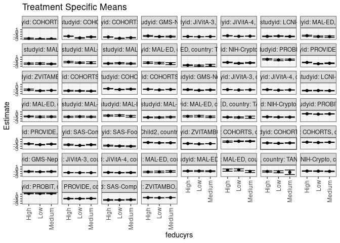

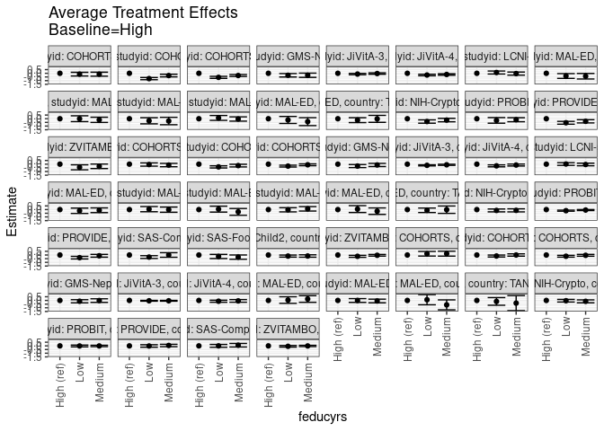

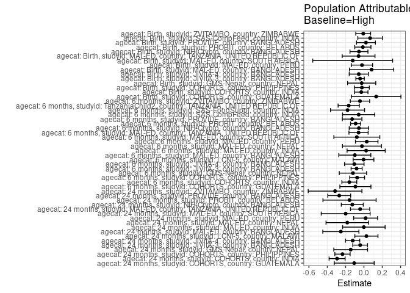

## Results Table

### Parameter: TSM

| agecat | studyid | country | intervention_level | baseline_level | estimate | ci_lower | ci_upper |
| --- | --- | --- | --- | --- | --- | --- | --- |
| Birth | COHORTS | GUATEMALA | High | NA | 0.0037010 | -0.2811134 | 0.2885155 |
| Birth | COHORTS | GUATEMALA | Low | NA | 0.1754156 | 0.0404012 | 0.3104299 |
| Birth | COHORTS | GUATEMALA | Medium | NA | 0.1862447 | 0.0130279 | 0.3594616 |
| Birth | COHORTS | INDIA | High | NA | -0.5722219 | -0.6671569 | -0.4772869 |
| Birth | COHORTS | INDIA | Low | NA | -0.7073342 | -0.8049757 | -0.6096927 |
| Birth | COHORTS | INDIA | Medium | NA | -0.5700630 | -0.6971894 | -0.4429366 |
| Birth | COHORTS | PHILIPPINES | High | NA | -0.2185038 | -0.3100752 | -0.1269325 |
| Birth | COHORTS | PHILIPPINES | Low | NA | -0.3865473 | -0.4716389 | -0.3014557 |
| Birth | COHORTS | PHILIPPINES | Medium | NA | -0.2597776 | -0.3452492 | -0.1743060 |
| Birth | GMS-Nepal | NEPAL | High | NA | -1.0640258 | -1.2365137 | -0.8915378 |
| Birth | GMS-Nepal | NEPAL | Low | NA | -1.1730374 | -1.2980748 | -1.0479999 |
| Birth | GMS-Nepal | NEPAL | Medium | NA | -1.0813673 | -1.2555721 | -0.9071624 |
| Birth | JiVitA-3 | BANGLADESH | High | NA | -1.5423616 | -1.5927764 | -1.4919469 |
| Birth | JiVitA-3 | BANGLADESH | Low | NA | -1.5875338 | -1.6188410 | -1.5562267 |
| Birth | JiVitA-3 | BANGLADESH | Medium | NA | -1.5891198 | -1.6225185 | -1.5557211 |
| Birth | JiVitA-4 | BANGLADESH | High | NA | -1.4679770 | -1.5761438 | -1.3598103 |
| Birth | JiVitA-4 | BANGLADESH | Low | NA | -1.5730738 | -1.6606689 | -1.4854787 |
| Birth | JiVitA-4 | BANGLADESH | Medium | NA | -1.5283262 | -1.6699689 | -1.3866836 |
| Birth | MAL-ED | BANGLADESH | High | NA | -1.2444661 | -1.5283839 | -0.9605484 |
| Birth | MAL-ED | BANGLADESH | Low | NA | -1.1906539 | -1.5368500 | -0.8444578 |
| Birth | MAL-ED | BANGLADESH | Medium | NA | -1.0479571 | -1.3942860 | -0.7016282 |
| Birth | MAL-ED | PERU | High | NA | -0.8429897 | -1.0123786 | -0.6736007 |
| Birth | MAL-ED | PERU | Low | NA | -0.8487863 | -1.0675864 | -0.6299863 |
| Birth | MAL-ED | PERU | Medium | NA | -0.9157949 | -1.1196856 | -0.7119042 |
| Birth | MAL-ED | SOUTH AFRICA | High | NA | -0.4350000 | -0.9433959 | 0.0733959 |
| Birth | MAL-ED | SOUTH AFRICA | Low | NA | -0.3378571 | -0.8038006 | 0.1280863 |
| Birth | MAL-ED | SOUTH AFRICA | Medium | NA | -1.0355556 | -1.4792485 | -0.5918626 |
| Birth | MAL-ED | TANZANIA, UNITED REPUBLIC OF | High | NA | -1.0323355 | -1.3116578 | -0.7530132 |
| Birth | MAL-ED | TANZANIA, UNITED REPUBLIC OF | Low | NA | -1.1697714 | -1.6073960 | -0.7321468 |
| Birth | MAL-ED | TANZANIA, UNITED REPUBLIC OF | Medium | NA | -1.3959510 | -2.3852602 | -0.4066417 |

[output cut: 126 more lines]

### Parameter: E(Y)

| agecat | studyid | country | intervention_level | baseline_level | estimate | ci_lower | ci_upper |
| --- | --- | --- | --- | --- | --- | --- | --- |
| Birth | COHORTS | GUATEMALA | NA | NA | 0.1369030 | 0.0500914 | 0.2237146 |
| Birth | COHORTS | INDIA | NA | NA | -0.6011965 | -0.6594222 | -0.5429708 |
| Birth | COHORTS | PHILIPPINES | NA | NA | -0.2407379 | -0.2807613 | -0.2007145 |
| Birth | GMS-Nepal | NEPAL | NA | NA | -1.0885159 | -1.1686181 | -1.0084136 |
| Birth | JiVitA-3 | BANGLADESH | NA | NA | -1.5843618 | -1.6039583 | -1.5647653 |
| Birth | JiVitA-4 | BANGLADESH | NA | NA | -1.5242226 | -1.5742923 | -1.4741529 |
| Birth | MAL-ED | BANGLADESH | NA | NA | -1.1609302 | -1.3461119 | -0.9757486 |
| Birth | MAL-ED | PERU | NA | NA | -0.8645361 | -0.9887014 | -0.7403707 |
| Birth | MAL-ED | SOUTH AFRICA | NA | NA | -0.5575758 | -0.8541170 | -0.2610345 |
| Birth | MAL-ED | TANZANIA, UNITED REPUBLIC OF | NA | NA | -1.0906796 | -1.3207118 | -0.8606474 |
| Birth | NIH-Crypto | BANGLADESH | NA | NA | -0.9094945 | -0.9809370 | -0.8380521 |
| Birth | PROBIT | BELARUS | NA | NA | 1.3196253 | 1.1597759 | 1.4794747 |
| Birth | PROVIDE | BANGLADESH | NA | NA | -0.8851020 | -0.9601332 | -0.8100709 |
| Birth | SAS-CompFeed | INDIA | NA | NA | -1.4300160 | -1.5090211 | -1.3510109 |
| Birth | ZVITAMBO | ZIMBABWE | NA | NA | -0.4977261 | -0.5185420 | -0.4769102 |
| 6 months | COHORTS | GUATEMALA | NA | NA | -1.8074115 | -1.8776669 | -1.7371562 |
| 6 months | COHORTS | INDIA | NA | NA | -0.9755018 | -1.0332483 | -0.9177553 |
| 6 months | COHORTS | PHILIPPINES | NA | NA | -1.1419345 | -1.1847445 | -1.0991244 |
| 6 months | GMS-Nepal | NEPAL | NA | NA | -1.3525459 | -1.4308373 | -1.2742545 |
| 6 months | JiVitA-3 | BANGLADESH | NA | NA | -1.3073109 | -1.3309979 | -1.2836240 |
| 6 months | JiVitA-4 | BANGLADESH | NA | NA | -1.3420154 | -1.3798750 | -1.3041557 |
| 6 months | LCNI-5 | MALAWI | NA | NA | -1.6442734 | -1.7137349 | -1.5748119 |
| 6 months | MAL-ED | BANGLADESH | NA | NA | -1.0786869 | -1.2229595 | -0.9344142 |
| 6 months | MAL-ED | INDIA | NA | NA | -1.0820652 | -1.2263805 | -0.9377499 |
| 6 months | MAL-ED | NEPAL | NA | NA | -0.6179474 | -0.8011766 | -0.4347182 |
| 6 months | MAL-ED | PERU | NA | NA | -1.3208519 | -1.4383850 | -1.2033189 |
| 6 months | MAL-ED | SOUTH AFRICA | NA | NA | -0.9829167 | -1.1753367 | -0.7904967 |
| 6 months | MAL-ED | TANZANIA, UNITED REPUBLIC OF | NA | NA | -1.3283002 | -1.4654809 | -1.1911194 |
| 6 months | NIH-Crypto | BANGLADESH | NA | NA | -1.1986783 | -1.2700937 | -1.1272630 |
| 6 months | PROBIT | BELARUS | NA | NA | 0.1078936 | 0.0168981 | 0.1988891 |
| 6 months | PROVIDE | BANGLADESH | NA | NA | -1.0916915 | -1.1661176 | -1.0172654 |
| 6 months | SAS-CompFeed | INDIA | NA | NA | -1.4006377 | -1.4802862 | -1.3209891 |
| 6 months | SAS-FoodSuppl | INDIA | NA | NA | -1.8986842 | -2.0118892 | -1.7854792 |
| 6 months | TanzaniaChild2 | TANZANIA, UNITED REPUBLIC OF | NA | NA | -0.5442042 | -0.5932639 | -0.4951446 |
| 6 months | ZVITAMBO | ZIMBABWE | NA | NA | -0.8606958 | -0.8865994 | -0.8347923 |
| 24 months | COHORTS | GUATEMALA | NA | NA | -2.9834879 | -3.0503374 | -2.9166384 |
| 24 months | COHORTS | INDIA | NA | NA | -2.1479058 | -2.2089283 | -2.0868833 |
| 24 months | COHORTS | PHILIPPINES | NA | NA | -2.4268626 | -2.4728444 | -2.3808807 |
| 24 months | GMS-Nepal | NEPAL | NA | NA | -1.8889117 | -1.9744778 | -1.8033456 |
| 24 months | JiVitA-3 | BANGLADESH | NA | NA | -2.0070517 | -2.0348225 | -1.9792810 |
| 24 months | JiVitA-4 | BANGLADESH | NA | NA | -1.7817125 | -1.8182569 | -1.7451681 |
| 24 months | LCNI-5 | MALAWI | NA | NA | -1.8787566 | -1.9605168 | -1.7969964 |
| 24 months | MAL-ED | BANGLADESH | NA | NA | -1.8767521 | -2.0339896 | -1.7195147 |
| 24 months | MAL-ED | INDIA | NA | NA | -1.8269318 | -1.9896129 | -1.6642507 |
| 24 months | MAL-ED | NEPAL | NA | NA | -1.3417582 | -1.5289233 | -1.1545932 |
| 24 months | MAL-ED | PERU | NA | NA | -1.7589939 | -1.8878675 | -1.6301203 |
| 24 months | MAL-ED | SOUTH AFRICA | NA | NA | -1.6565385 | -1.8628022 | -1.4502747 |
| 24 months | MAL-ED | TANZANIA, UNITED REPUBLIC OF | NA | NA | -2.5846893 | -2.7309103 | -2.4384682 |
| 24 months | NIH-Crypto | BANGLADESH | NA | NA | -1.4412646 | -1.5249156 | -1.3576135 |
| 24 months | PROBIT | BELARUS | NA | NA | -0.1374857 | -0.4188811 | 0.1439096 |
| 24 months | PROVIDE | BANGLADESH | NA | NA | -1.6024221 | -1.6857420 | -1.5191023 |
| 24 months | ZVITAMBO | ZIMBABWE | NA | NA | -1.5903795 | -1.6477380 | -1.5330211 |

### Parameter: ATE

| agecat | studyid | country | intervention_level | baseline_level | estimate | ci_lower | ci_upper |
| --- | --- | --- | --- | --- | --- | --- | --- |
| Birth | COHORTS | GUATEMALA | High | High | 0.0000000 | 0.0000000 | 0.0000000 |
| Birth | COHORTS | GUATEMALA | Low | High | 0.1717145 | -0.1433889 | 0.4868180 |
| Birth | COHORTS | GUATEMALA | Medium | High | 0.1825437 | -0.1509171 | 0.5160045 |
| Birth | COHORTS | INDIA | High | High | 0.0000000 | 0.0000000 | 0.0000000 |
| Birth | COHORTS | INDIA | Low | High | -0.1351123 | -0.2679103 | -0.0023143 |
| Birth | COHORTS | INDIA | Medium | High | 0.0021589 | -0.1532016 | 0.1575194 |
| Birth | COHORTS | PHILIPPINES | High | High | 0.0000000 | 0.0000000 | 0.0000000 |
| Birth | COHORTS | PHILIPPINES | Low | High | -0.1680435 | -0.2915331 | -0.0445540 |
| Birth | COHORTS | PHILIPPINES | Medium | High | -0.0412738 | -0.1645540 | 0.0820065 |
| Birth | GMS-Nepal | NEPAL | High | High | 0.0000000 | 0.0000000 | 0.0000000 |
| Birth | GMS-Nepal | NEPAL | Low | High | -0.1090116 | -0.3199252 | 0.1019020 |
| Birth | GMS-Nepal | NEPAL | Medium | High | -0.0173415 | -0.2600012 | 0.2253182 |
| Birth | JiVitA-3 | BANGLADESH | High | High | 0.0000000 | 0.0000000 | 0.0000000 |
| Birth | JiVitA-3 | BANGLADESH | Low | High | -0.0451722 | -0.1004401 | 0.0100957 |
| Birth | JiVitA-3 | BANGLADESH | Medium | High | -0.0467582 | -0.1020238 | 0.0085074 |
| Birth | JiVitA-4 | BANGLADESH | High | High | 0.0000000 | 0.0000000 | 0.0000000 |
| Birth | JiVitA-4 | BANGLADESH | Low | High | -0.1050967 | -0.2436647 | 0.0334712 |
| Birth | JiVitA-4 | BANGLADESH | Medium | High | -0.0603492 | -0.2385226 | 0.1178242 |
| Birth | MAL-ED | BANGLADESH | High | High | 0.0000000 | 0.0000000 | 0.0000000 |
| Birth | MAL-ED | BANGLADESH | Low | High | 0.0538122 | -0.3955259 | 0.5031503 |
| Birth | MAL-ED | BANGLADESH | Medium | High | 0.1965090 | -0.2530298 | 0.6460479 |
| Birth | MAL-ED | PERU | High | High | 0.0000000 | 0.0000000 | 0.0000000 |
| Birth | MAL-ED | PERU | Low | High | -0.0057967 | -0.2603315 | 0.2487382 |
| Birth | MAL-ED | PERU | Medium | High | -0.0728052 | -0.3192171 | 0.1736066 |
| Birth | MAL-ED | SOUTH AFRICA | High | High | 0.0000000 | 0.0000000 | 0.0000000 |
| Birth | MAL-ED | SOUTH AFRICA | Low | High | 0.0971429 | -0.5924727 | 0.7867584 |
| Birth | MAL-ED | SOUTH AFRICA | Medium | High | -0.6005556 | -1.2753368 | 0.0742257 |
| Birth | MAL-ED | TANZANIA, UNITED REPUBLIC OF | High | High | 0.0000000 | 0.0000000 | 0.0000000 |
| Birth | MAL-ED | TANZANIA, UNITED REPUBLIC OF | Low | High | -0.1374359 | -0.6597103 | 0.3848385 |
| Birth | MAL-ED | TANZANIA, UNITED REPUBLIC OF | Medium | High | -0.3636155 | -1.3927821 | 0.6655511 |

[output cut: 126 more lines]

### Parameter: PAR

| agecat | studyid | country | intervention_level | baseline_level | estimate | ci_lower | ci_upper |
| --- | --- | --- | --- | --- | --- | --- | --- |
| Birth | COHORTS | GUATEMALA | High | NA | 0.1332019 | -0.1370667 | 0.4034706 |
| Birth | COHORTS | INDIA | High | NA | -0.0289745 | -0.1019986 | 0.0440495 |
| Birth | COHORTS | PHILIPPINES | High | NA | -0.0222341 | -0.1033210 | 0.0588528 |
| Birth | GMS-Nepal | NEPAL | High | NA | -0.0244901 | -0.1783235 | 0.1293434 |
| Birth | JiVitA-3 | BANGLADESH | High | NA | -0.0420002 | -0.0881007 | 0.0041003 |
| Birth | JiVitA-4 | BANGLADESH | High | NA | -0.0562456 | -0.1605581 | 0.0480670 |
| Birth | MAL-ED | BANGLADESH | High | NA | 0.0835359 | -0.1580738 | 0.3251456 |
| Birth | MAL-ED | PERU | High | NA | -0.0215464 | -0.1375440 | 0.0944512 |
| Birth | MAL-ED | SOUTH AFRICA | High | NA | -0.1225758 | -0.5581866 | 0.3130351 |
| Birth | MAL-ED | TANZANIA, UNITED REPUBLIC OF | High | NA | -0.0583441 | -0.2374398 | 0.1207515 |
| Birth | NIH-Crypto | BANGLADESH | High | NA | -0.0541341 | -0.1520194 | 0.0437511 |
| Birth | PROBIT | BELARUS | High | NA | -0.0118013 | -0.1001981 | 0.0765955 |
| Birth | PROVIDE | BANGLADESH | High | NA | 0.0221920 | -0.0808940 | 0.1252780 |
| Birth | SAS-CompFeed | INDIA | High | NA | 0.0674444 | -0.0667026 | 0.2015914 |
| Birth | ZVITAMBO | ZIMBABWE | High | NA | -0.0079809 | -0.0889016 | 0.0729397 |
| 6 months | COHORTS | GUATEMALA | High | NA | -0.0930739 | -0.2626197 | 0.0764719 |
| 6 months | COHORTS | INDIA | High | NA | -0.1593441 | -0.2404404 | -0.0782478 |
| 6 months | COHORTS | PHILIPPINES | High | NA | -0.0741832 | -0.1553416 | 0.0069751 |
| 6 months | GMS-Nepal | NEPAL | High | NA | -0.1201002 | -0.2692322 | 0.0290319 |
| 6 months | JiVitA-3 | BANGLADESH | High | NA | -0.0797637 | -0.1401092 | -0.0194182 |
| 6 months | JiVitA-4 | BANGLADESH | High | NA | -0.1053478 | -0.2118644 | 0.0011689 |
| 6 months | LCNI-5 | MALAWI | High | NA | -0.0043588 | -0.1175013 | 0.1087836 |
| 6 months | MAL-ED | BANGLADESH | High | NA | -0.0993912 | -0.2741439 | 0.0753615 |
| 6 months | MAL-ED | INDIA | High | NA | 0.0240904 | -0.1840971 | 0.2322778 |
| 6 months | MAL-ED | NEPAL | High | NA | -0.0216663 | -0.2341585 | 0.1908260 |
| 6 months | MAL-ED | PERU | High | NA | 0.0305770 | -0.0921498 | 0.1533037 |
| 6 months | MAL-ED | SOUTH AFRICA | High | NA | -0.0773199 | -0.3279646 | 0.1733247 |
| 6 months | MAL-ED | TANZANIA, UNITED REPUBLIC OF | High | NA | -0.0587136 | -0.1634976 | 0.0460704 |
| 6 months | NIH-Crypto | BANGLADESH | High | NA | -0.0546411 | -0.1607091 | 0.0514269 |
| 6 months | PROBIT | BELARUS | High | NA | -0.0907669 | -0.1458458 | -0.0356880 |
| 6 months | PROVIDE | BANGLADESH | High | NA | -0.1288395 | -0.2356034 | -0.0220757 |
| 6 months | SAS-CompFeed | INDIA | High | NA | -0.0574328 | -0.2330464 | 0.1181807 |
| 6 months | SAS-FoodSuppl | INDIA | High | NA | -0.1788862 | -0.3648273 | 0.0070549 |
| 6 months | TanzaniaChild2 | TANZANIA, UNITED REPUBLIC OF | High | NA | -0.1659224 | -0.2818155 | -0.0500292 |
| 6 months | ZVITAMBO | ZIMBABWE | High | NA | -0.0432088 | -0.1489350 | 0.0625173 |
| 24 months | COHORTS | GUATEMALA | High | NA | -0.1060636 | -0.3241984 | 0.1120712 |
| 24 months | COHORTS | INDIA | High | NA | -0.2928071 | -0.3801799 | -0.2054342 |
| 24 months | COHORTS | PHILIPPINES | High | NA | -0.2339234 | -0.3171434 | -0.1507035 |
| 24 months | GMS-Nepal | NEPAL | High | NA | -0.1444270 | -0.3287582 | 0.0399043 |
| 24 months | JiVitA-3 | BANGLADESH | High | NA | -0.0411460 | -0.1214661 | 0.0391741 |
| 24 months | JiVitA-4 | BANGLADESH | High | NA | -0.1228321 | -0.2001125 | -0.0455516 |
| 24 months | LCNI-5 | MALAWI | High | NA | 0.0269817 | -0.0992238 | 0.1531873 |
| 24 months | MAL-ED | BANGLADESH | High | NA | -0.2518668 | -0.4488432 | -0.0548904 |
| 24 months | MAL-ED | INDIA | High | NA | -0.0007908 | -0.2327646 | 0.2311830 |
| 24 months | MAL-ED | NEPAL | High | NA | -0.1815803 | -0.4138100 | 0.0506494 |
| 24 months | MAL-ED | PERU | High | NA | 0.0185517 | -0.1126349 | 0.1497382 |
| 24 months | MAL-ED | SOUTH AFRICA | High | NA | -0.1991764 | -0.4660452 | 0.0676923 |
| 24 months | MAL-ED | TANZANIA, UNITED REPUBLIC OF | High | NA | -0.0416531 | -0.1467394 | 0.0634333 |
| 24 months | NIH-Crypto | BANGLADESH | High | NA | -0.1271221 | -0.2469330 | -0.0073112 |
| 24 months | PROBIT | BELARUS | High | NA | -0.1570340 | -0.4470726 | 0.1330047 |
| 24 months | PROVIDE | BANGLADESH | High | NA | -0.2694289 | -0.3941695 | -0.1446883 |
| 24 months | ZVITAMBO | ZIMBABWE | High | NA | -0.3149933 | -0.6081997 | -0.0217869 |